# STA 483 - Final Project

Thai Huynh, Hongfei Shou, Fengling Jiang

2023-04-23

### Data Preparation and Manipulation

The data sets show the the monthly number of job losers due to layoffs in The United States from January 1967 to March 2023 (in thousand).

```r
# Read in the data set
layoff <- read.csv("LNU03023653.csv")
names(layoff) <- c("date", "jobs") # Rename the variables
# Convert the data into time series
layoff_ts <- ts(layoff$jobs, start=c(1967, 1), end=c(2023, 3), frequency = 12)
# Take a look at the time series
glimpse(layoff_ts)
```

```
##  Time-Series [1:675] from 1967 to 2023: 567 511 461 415 358 332 409 385 301 299 ...
```

### Exploratory Data Analysis

First of all, we take an initial look at the data by examining its time series plot and the distribution of the data through its density plot.

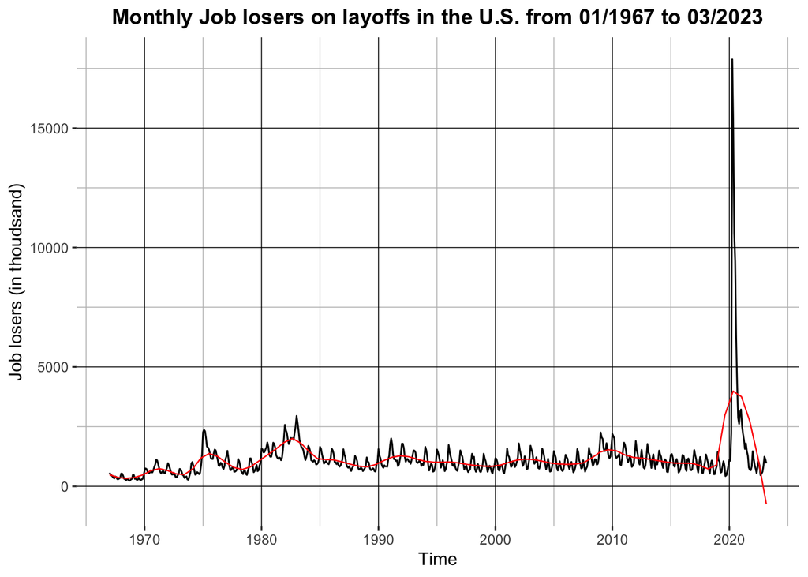

```r
autoplot(layoff_ts)+
  geom_smooth(se = FALSE, span = 0.1, color = "red", size=0.4) +
  labs(title="Monthly Job losers on layoffs in the U.S. from 01/1967 to 03/2023",
       y="Job losers (in thoudsand)")+
  theme(plot.title = element_text(hjust=0.5, face = "bold"))+
  theme(panel.background = element_rect(fill="white"),
        panel.grid.major = element_line(color="black", size = 0.25),
        panel.grid.minor = element_line(color="gray", size = 0.25))
```

The above plot shows the time series of monthly job losers due to layoffs in the U.S for the period between 01/1967 and 03/2023. We observed some noticeable rise in the number of job lost in the history. For example, in around the year 1975, there was possibly an impact of layoff on the labor market. The period from 1982-1985 also witnessed an easily detected rise in the job loss due to layoffs. The most important behavior that we can see in the time series plot is the really huge spike in the period between 2020 and 2022. It might be inferred that there are influential mass layoffs that happened nationwide.

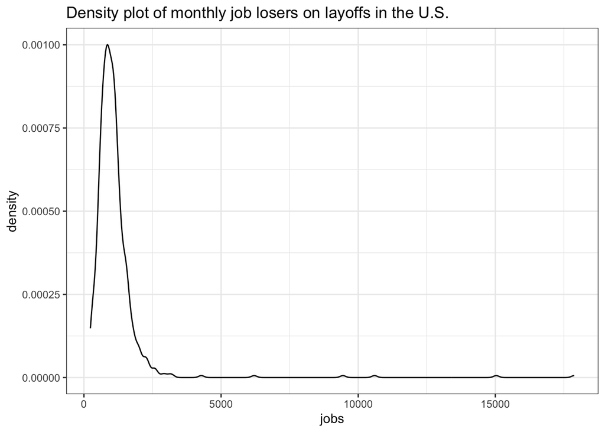

```r
ggplot()+
  geom_density(aes(x=jobs), data=layoff)+
  labs(title="Density plot of monthly job losers on layoffs in the U.S.")+
  theme_bw()
```

We see that the data is skewed to the right. The fact that the number of job losers skyrocketed in the period around 2020-2022 makes our data have a long tail to the right.

**Strategy:** Because the aforementioned huge spike in the time series could possibly hinder our analysis, we choose to split the data into the training set and the testing set at the beginning. By doing this, we exclude the presence of that spike in our model selection process. We will train our model and examine its prediction accuracy on the testing set to see that is there any chance our best model can take into account such a standout pattern in the time series.

```r
# We split the data into training set and testing set at the beginning
layoff.train <- window(layoff_ts, end=c(2015, 12), frequency=12)
layoff.test <- window(layoff_ts, start=c(2016,1), end=c(2023,3), frequency=12)
```

We split the data into training set and test set. The training set contains data from 01/1967 to 12/2015. The test set will containing the last 7 years (2016-2022) and the 3 months of 2023. We make sure that our testing set contains the entire period that concerned the huge spike.

**Check Stationarity**

Non-stationary time series are erratic and unpredictable while stationary process is mean-reverting, i.e, it fluctuates around a constant mean with constant variance. In addition, stationarity and independence of random variables are closely related because many theories that hold for independent random variables also hold for stationary time series in which independence is a required condition. The majority of these methods assume the random variables are independent (or uncorrelated); the noise is independent (or uncorrelated); and the variable and noise are independent (or uncorrelated) of each other. Roughly speaking, stationary time series shows no long-term trend, has constant mean and variance.

We fit the time series again; however, this time we already excluded the impact of the huge spike in the time series. The period covered in the time series is from January 1967 to December 2015.

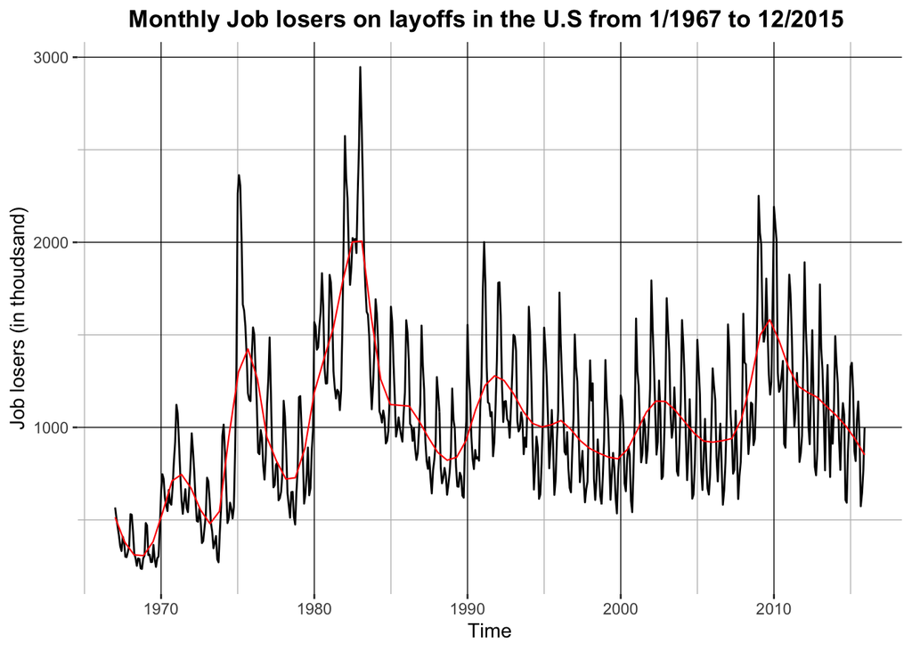

```r
autoplot(layoff.train)+
  geom_smooth(se = FALSE, span = 0.1, color = "red", size=0.4) +
  labs(title="Monthly Job losers on layoffs in the U.S from 1/1967 to 12/2015 ",
       y="Job losers (in thoudsand)")+
  theme(plot.title = element_text(hjust=0.5, face = "bold"),
        plot.subtitle = element_text(hjust=0.5))+
  theme(panel.background = element_rect(fill="white"),
        panel.grid.major = element_line(color="black", size = 0.25),
        panel.grid.minor = element_line(color="gray", size = 0.25))
```

We check stationarity of the time series by examining the above time series plot. The job losers on layoffs in the U.S. show no clear trend, either upward or downward. It seems to fluctuate over the whole period. In addition to that, there seems to appear a seasonality pattern in the time series.

Around the years from 1975-1978, there is a first noticeable increase in the number of job losers. Based on our research, New York City in the late 1970s was plagued by severe economic and political troubles. Faced with economic stagnation, industrial decline, and the looming threat of bankruptcy, the City of New York responded by laying off city workers and cutting municipal services such as sanitation and after-school programs. So, this may be a good explanation for such an increase.

The second notable period is from 1982-1985. The early 1980s recession could be the answer for the increase in job loss that we observed in that period.

Another noteworthy spike is from 2008 to 2012. There is lots of possibility that the Great Recession is held accountable.

Furthermore, we may try decomposing the time series into separate components for more detailed examination.

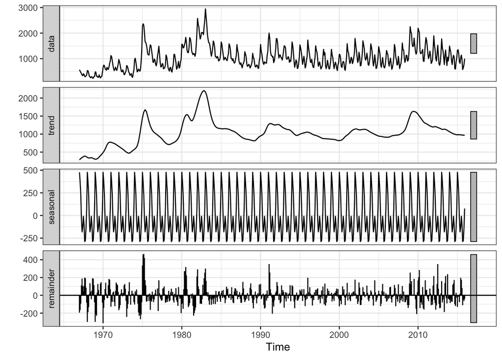

```r
# Decompose the time series into different components
autoplot(stl(layoff.train, s.window = "periodic"))+
  theme_bw()
```

The above figure shows an additive decomposition of these data. The method used for estimating components in this example is STL.

STL is a versatile and robust method for decomposing time series. STL is an acronym for “Seasonal and Trend decomposition using Loess”, while Loess is a method for estimating nonlinear relationships. The STL method was developed by R. B. Cleveland, Cleveland, McRae, & Terpenning (1990). (Reference: Cleveland, R. B., Cleveland, W. S., McRae, J. E., & Terpenning, I. J. (1990). STL: A seasonal-trend decomposition procedure based on loess. Journal of Official Statistics, 6(1), 3–33. http://bit.ly/stl1990)

The three components are shown separately in the bottom three panels. These components can be added together to reconstruct the data shown in the top panel. The seasonal component does not change over time. The remainder component shown in the bottom panel is what is left over when the seasonal and trend-cycle components have been subtracted from the data.

Besides graphical diagnostics, we can utilize Dickey-Fuller test to check the stationarity of the time series.

```r
# Dickey-Fuller test
adf.test(layoff.train)
```

```
##
##  Augmented Dickey-Fuller Test
##
## data:  layoff.train
## Dickey-Fuller = -2.6645, Lag order = 8, p-value = 0.297
## alternative hypothesis: stationary
```

The null hypothesis of the test fundamentally assumes the presence of unit root. And the presence of a unit root means the time series is non-stationary. The p-value generated is much larger than 0.05. Therefore at 5% significance level, we can conclude that the time series is not stationary. This is consistent with our observations from the above graphical diagnostics.

**Check Normality**

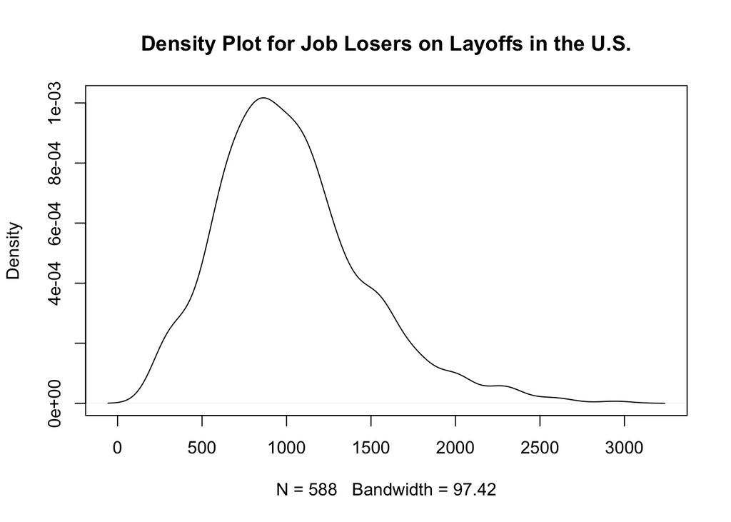

```r
# The density plot
plot(density(layoff.train), main="Density Plot for Job Losers on Layoffs in the U.S.")
```

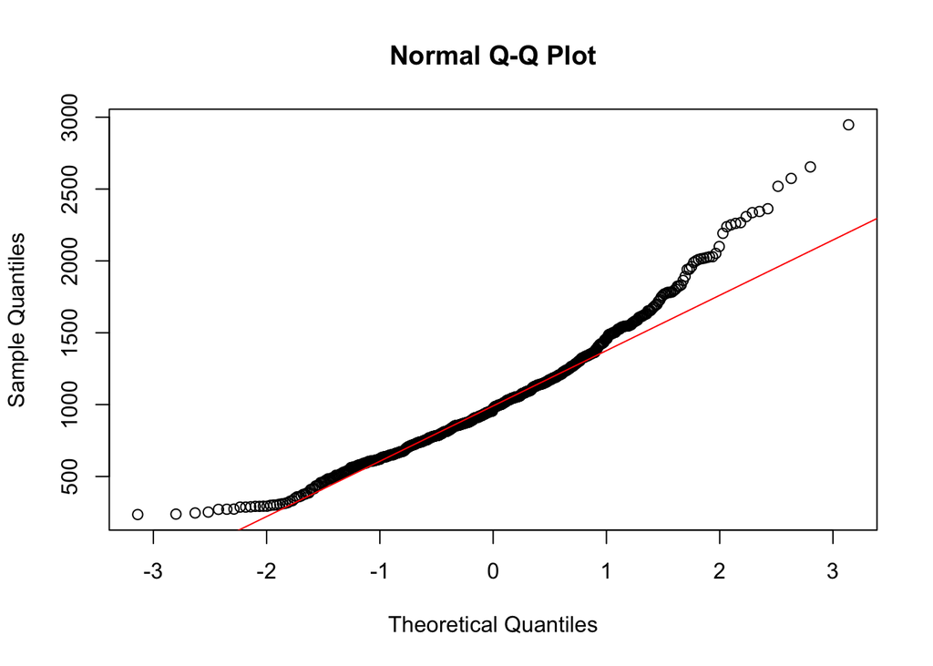

```r
# Normal QQ Plot
qqnorm(layoff.train)
qqline(y=layoff.train, col="red")
```

The distributional shape of the job losers can also be explored by constructing a QQ normal scores plot. The QQ plot shows that data points depart from the normality line at the end. That is, the normality of data is not truly guaranteed but not seriously violated either.

```r
# Shapiro-Wilk Test for Normality
shapiro.test(layoff.train)
```

```
##
##  Shapiro-Wilk normality test
##
## data:  layoff.train
## W = 0.95753, p-value = 5.492e-12
```

The Shapiro-Wilk test statistic for testing normality is much less than 0.05, and hence we reject the normality hypothesis at the usual significance levels. In order to confirm our graphical observation and statistical test, we implemented some more techniques in order to check normality.

```r
# Kurtosis
kurtosis(layoff.train)
```

```
## [1] 1.175357
```

```r
# Jarque-Bera test for normality
jarque.bera.test(layoff.train)
```

```
##
##  Jarque Bera Test
##
## data:  layoff.train
## X-squared = 109.34, df = 2, p-value < 2.2e-16
```

The kurtosis is positive, indicating heavy-tailed distribution. The Jarque-Bera test concludes that the data is not normally distributed. As a result, our conclusion about the normality of the data is reinforced using various methods that yield the consistent finding.

**ACF and PACF plot**

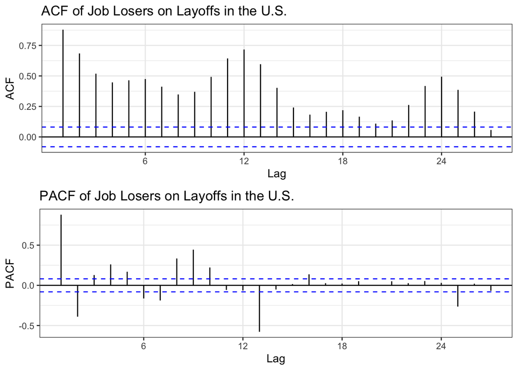

```r
# The ACF and PACF plots of the Job Losers on Layoffs
grid.arrange(ggAcf(layoff.train)+ theme_bw()+ggtitle("ACF of Job Losers on Layoffs in the U.S."),
             ggPacf(layoff.train)+theme_bw()+ggtitle("PACF of Job Losers on Layoffs in the U.S."))
```

Autocorrelation is the correlation between a time series with a lagged version of itself. Therefore, ACF plot describes how well the present value of the series is related with its past values. There are several significant autocorrelations in the ACF plot and in the PACF plot. There are significant autocorrelations between subsequent lags. Because of several autocorrelations that are significantly non-zero, the time series is non-random. In fact, these plots do not indicate any readily apparent behavior of AR or MA process. Also, the ACF plot shows repeated behavior. This is very characteristic of seasonal time series and behaviour of this sort in a correlogram is usually indicative that seasonality/periodic effects have not fully been accounted for in a model.

Thus, these autocorrelations furnish some evidence against the hypothesis that the data are independently and identically distributed.

**Check the existence of an ARCH effect**

We apply the McLeod-Li test for ARCH using a number of lags and plot the p-values of the test.

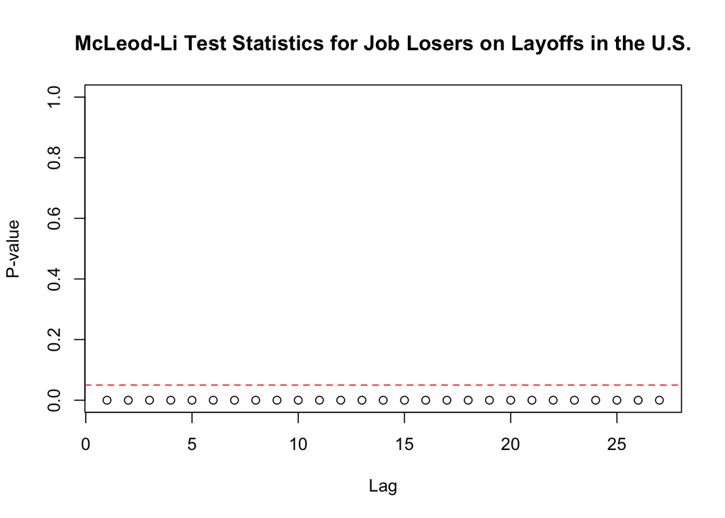

```r
# McLeod-Li test
McLeod.Li.test(y=layoff.train, main="McLeod-Li Test Statistics for Job Losers on Layoffs in the U.S.")
```

```r
# ARCH LM test
ArchTest(layoff.train, lags=5, demean=TRUE)
```

```
##
##  ARCH LM-test; Null hypothesis: no ARCH effects
##
## data:  layoff.train
## Chi-squared = 413.75, df = 5, p-value < 2.2e-16
```

The null hypothesis of ARCH-LM test is there is no ARCH effect. Here the ARCH effect means the correlation between $Y_t^2$ and $Y_{t-1}^2,\dots,Y_{t-p}^2$. The small p-value provides stronger evidence against the null hypothesis. The ARCH LM test yields the same conclusion that there is the presence of ARCH effect in the data since we reject the null hypothesis.

### Model Selection

**SARIMA model**

The fact that the time series is not stationary and the observation in the ACF and PACF plot suggests us to use differencing method to make the time series stationary. In addition to that, the seasonality pattern suggests a SARIMA model.

We use the function `auto.arima` to see what model is recommended.

```r
layoff.fit <- auto.arima(layoff.train)
summary(layoff.fit)
```

```
## Series: layoff.train
## ARIMA(3,0,3)(0,1,2)[12]
##
## Coefficients:
##          ar1     ar2     ar3     ma1     ma2     ma3     sma1     sma2
##       0.3629  -0.075  0.5862  0.5885  0.7091  0.1872  -0.7273  -0.0735
## s.e.  0.1115   0.147  0.1175  0.1144  0.1178  0.0465   0.0443   0.0419
##
## sigma^2 = 10083:  log likelihood = -3474.87
## AIC=6967.74   AICc=6968.06   BIC=7006.95
##
## Training set error measures:
##                    ME     RMSE      MAE        MPE     MAPE      MASE
## Training set 3.343086 98.69252 72.43905 -0.1744826 7.350393 0.3509744
##                     ACF1
## Training set 0.001411822
```

The recommended model is SARIMA model. It is in the form SARIMA(3,0,3)(0,1,2)[12].

Generally it has the form:

$$Y_t = \phi_1 Y_{t-1} + \phi_2Y_{t-2} +
\phi_3Y_{t-3} + Y_{t-12} - Y_{t-13} - \theta_1\epsilon_{t-1} -
\theta_2\epsilon_{t-2} - \theta_3\epsilon_{t-3} -\Theta_1\epsilon_{t-12}
+ \theta_1 \Theta_1\epsilon_{t-13} - \Theta_2\epsilon_{t-24} + \theta_1
\Theta_2\epsilon_{t-25} + \epsilon_t$$

Or using backshift operator:

$$(1 - \phi_1B^1 - \phi_2B^2 -
\phi_3B^3)(1-B^{12})Y_t = (1 + \theta_1B^1 + \theta_2B^2 +
\theta_3B^3)(1+\Theta_1B^{12} + \Theta_2B^{24})\epsilon_t$$

where

• B is the backshift operator, B$Y_t$ = $Y_{t-1}$

• the term $(1 - \phi_1B^1 - \phi_2B^2 - \phi_3B^3)$ comes from the AR(3) component

• the term $(1-B^{12})$ is the seasonal integration of order 1

• the term $(1 + \theta_1B^1 + \theta_2B^2 + \theta^3B^3)$ comes from the MA(3) component

• the term $(1+\Theta_1B^{12} + \Theta_2B^{24})$ comes from the $MA(2)_{12}$ component.

Using the above coefficients from the output, we can write the model accordingly:

$$Y_t = 0.363Y_{t-1} - 0.075Y_{t-2} +
0.586Y_{t-3} + Y_{t-12} - Y_{t-13} + 0.589\epsilon_{t-1} +
0.709\epsilon_{t-2} + 0.187\epsilon_{t-3} -0.727(\epsilon_{t-12} -
0.589\epsilon_{t - 13}) - 0.074(\epsilon_{t-24} - 0.589\epsilon_{t-25})+
\epsilon_t$$

$$Y_t = 0.363Y_{t-1} - 0.075Y_{t-2} +
0.586Y_{t-3} + Y_{t-12} - Y_{t-13} + 0.589\epsilon_{t-1} +
0.709\epsilon_{t-2} + 0.187\epsilon_{t-3} -0.727\epsilon_{t-12} +
0.428\epsilon_{t - 13} - 0.074\epsilon_{t-24} + 0.044\epsilon_{t-25}+
\epsilon_t$$

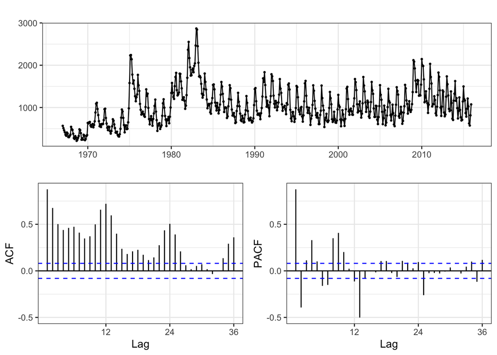

```r
# The fitted time series model
ggtsdisplay(fitted(layoff.fit), theme=theme_bw())
```

**Diagnostic Checking**

The procedure includes observing residual plot and its ACF & PACF diagram, and check Ljung-Box result. If ACF plot and PACF plot of the model residuals show no significant lags, the selected model is appropriate.

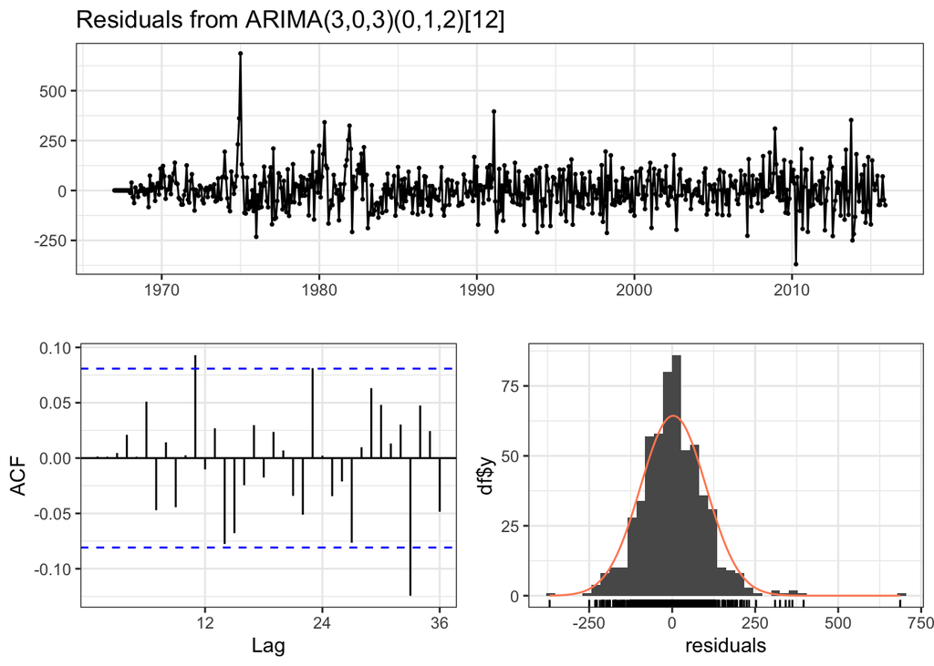

```
##
##  Ljung-Box test
##
## data:  Residuals from ARIMA(3,0,3)(0,1,2)[12]
## Q* = 33.021, df = 22, p-value = 0.06158
##
## Model df: 8.   Total lags used: 30
```

```r
# Residual analysis for the fitted SARIMA model
checkresiduals(layoff.fit, theme=theme_bw(), lag=30)
```

To check the residual analysis of the fitted SARIMA model, we use the Ljung-Box test for the first 30 selected lags. The p-value is larger than 0.05, hence we fail to reject the null hypothesis. We conclude that the fitted model is a pretty good model.

**Check for ARCH effect in the residuals**

```r
# ARCH LM test for the residuals of the model
ArchTest(layoff.fit$residuals, lags=5, demean=TRUE)
```

```
##
##  ARCH LM-test; Null hypothesis: no ARCH effects
##
## data:  layoff.fit$residuals
## Chi-squared = 36.635, df = 5, p-value = 7.089e-07
```

The p-value for the test is less than the significance level, the ARCH effect exists in the residual, meaning that the variance of the model is not constant. The time series plot of residuals shows concern of heteroscedasticity.

The ACF and PACF of squared residuals will help confirm if the residuals (noise term) are not independent and can be predicted. If the residuals are strict white noise, they are independent with zero mean, normally distributed, and the ACF plot and PACF plot of squared residuals display no significant lags. In other words, in order to verify we have selected the right model we need to check the squared residuals of the fitted model. These should behave as Gaussian white noise.

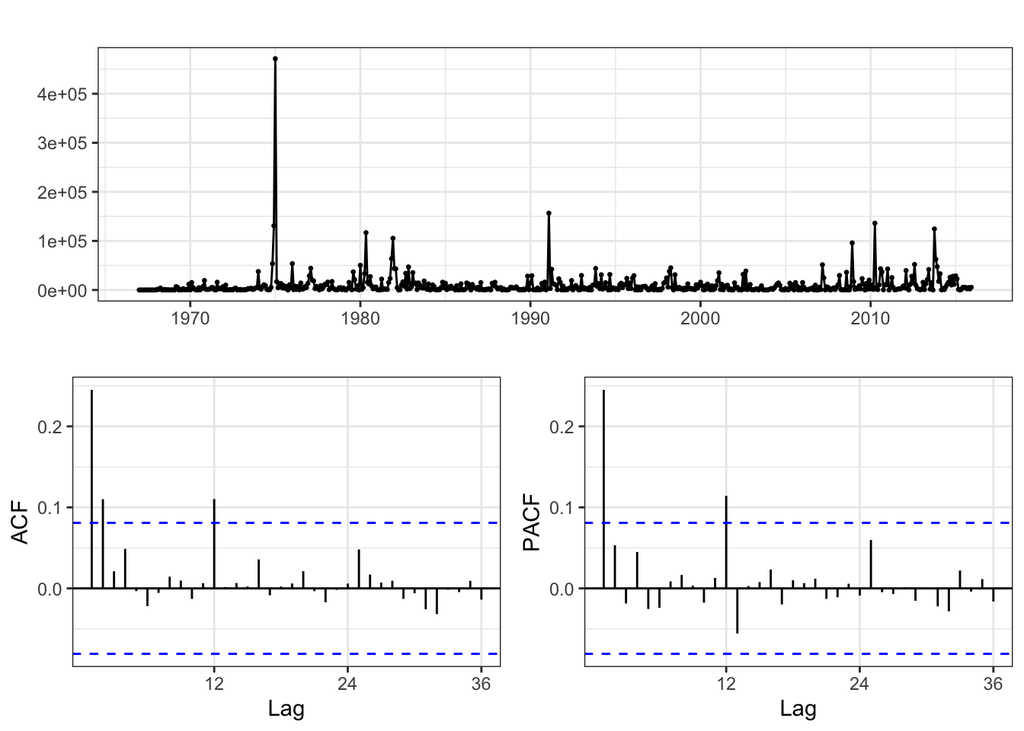

```r
# Check the squared residuals
ggtsdisplay(layoff.fit$residuals^2, theme=theme_bw())
```

An ARCH model implies variance-dependency, not mean-dependency. The residuals $\epsilon_t$ are assumed to have zero mean, hence if we look at these, we would check if the model exhibits autocorrelation. Hence, $\epsilon_t^2$ is a point-estimator for the error variance. If we check for a relation between $\epsilon_t^2$ ,we implicitly check for a relation between variances - which is what ARCH implies. In this case, the squared residuals show some patterns in the sense that ARCH/GARCH is necessary to model the volatility of the series.

ARIMA/SARIMA modelling is modelling of the mean level. ARCH modelling being associated with heteroscedasticity is modelling of the variance. Applying both together as ARMA-GARCH model we can model both mean and volatility at the same time.

**ARCH/GARCH model**

We can first try fitting ARCH(1) for the residuals

```r
# Fit the ARCH(1) model for the residuals
arch.fit=garchFit(~garch(1,0),layoff.fit$residuals)
```

```r
summary(arch.fit)
```

```
##
## Title:
##  GARCH Modelling
##
## Call:
##  garchFit(formula = ~garch(1, 0), data = layoff.fit$residuals)
##
## Mean and Variance Equation:
##  data ~ garch(1, 0)
## <environment: 0x7f98036e44a8>
##  [data = layoff.fit$residuals]
##
## Conditional Distribution:
##  norm
##
## Coefficient(s):
##         mu       omega      alpha1
##   -1.30754  6492.66842     0.31936
##
## Std. Errors:
##  based on Hessian
##
## Error Analysis:
##          Estimate  Std. Error  t value Pr(>|t|)
## mu       -1.30754     3.47396   -0.376    0.707
## omega  6492.66842   521.36099   12.453  < 2e-16 ***
## alpha1    0.31936     0.06927    4.610 4.02e-06 ***
## ---
## Signif. codes:  0 '***' 0.001 '**' 0.01 '*' 0.05 '.' 0.1 ' ' 1
##
## Log Likelihood:
##  -3499.797    normalized:  -5.952036
##
## Description:
##  Tue May  9 23:29:56 2023 by user:
##
##
## Standardised Residuals Tests:
##                                 Statistic p-Value
##  Jarque-Bera Test   R    Chi^2  74.21523  1.110223e-16
##  Shapiro-Wilk Test  R    W      0.9846666 7.574773e-06
##  Ljung-Box Test     R    Q(10)  8.562387  0.5740754
##  Ljung-Box Test     R    Q(15)  21.12153  0.1329911
##  Ljung-Box Test     R    Q(20)  22.0158   0.3396537
##  Ljung-Box Test     R^2  Q(10)  18.01164  0.05476761
##  Ljung-Box Test     R^2  Q(15)  23.03371  0.08342674
##  Ljung-Box Test     R^2  Q(20)  35.96312  0.01553531
##  LM Arch Test       R    TR^2   19.65467  0.07390702
##
## Information Criterion Statistics:
##      AIC      BIC      SIC     HQIC
## 11.91428 11.93661 11.91422 11.92298
```

The omega, and alpha1 of the model is significant; however, the mu is not significant. Therefore, the model has the form:

$$\epsilon_t=\sigma_te_t, \mbox{ where } \sigma_t^2= 6492.668
+0.319\epsilon_{t-1}^2.$$

$$Y_t = 0.363Y_{t-1} - 0.075Y_{t-2} +
0.586Y_{t-3} + Y_{t-12} - Y_{t-13} + 0.589\epsilon_{t-1} +
0.709\epsilon_{t-2} + 0.187\epsilon_{t-3} -0.727\epsilon_{t-12} +
0.428\epsilon_{t - 13} - 0.074\epsilon_{t-24} + 0.044\epsilon_{t-25}+
\epsilon_t$$
Where $\epsilon_t = \sqrt{\sigma_t^2= 6492.668 +0.319\epsilon_{t-1}^2}e_t$ and $e_t$ are independently and identically distributed noises with mean zero and variance one.

### Forecasting

Fore the forecasting purposes, we only use the SARIMA model. The complexity of using the hybrid SARIMA-ARCH model to make prediction is out of the scope of our research. However, we expect that our trained model will not be able to catch the “shock” in the testing set in the forecasting below:

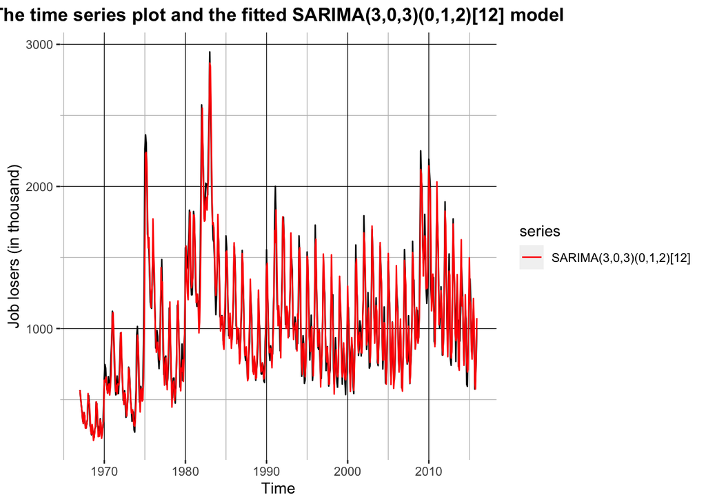

```r
autoplot(layoff.train)+
  autolayer(fitted(layoff.fit))+
  scale_colour_manual(values="red", label="SARIMA(3,0,3)(0,1,2)[12]")+
  labs(y= "Job losers (in thousand)",
       title = "The time series plot and the fitted SARIMA(3,0,3)(0,1,2)[12] model")+
  theme(plot.title = element_text(hjust=0.5, face = "bold"))+
  theme(panel.background = element_rect(fill="white"),
        panel.grid.major = element_line(color="black", size = 0.25),
        panel.grid.minor = element_line(color="gray", size = 0.25))
```

```r
# Make the forecasting
# Only show the first 10 predicted values
layoff.forecast <- forecast(layoff.fit, h=length(layoff.test))
layoff.forecast
```

[output not shown]

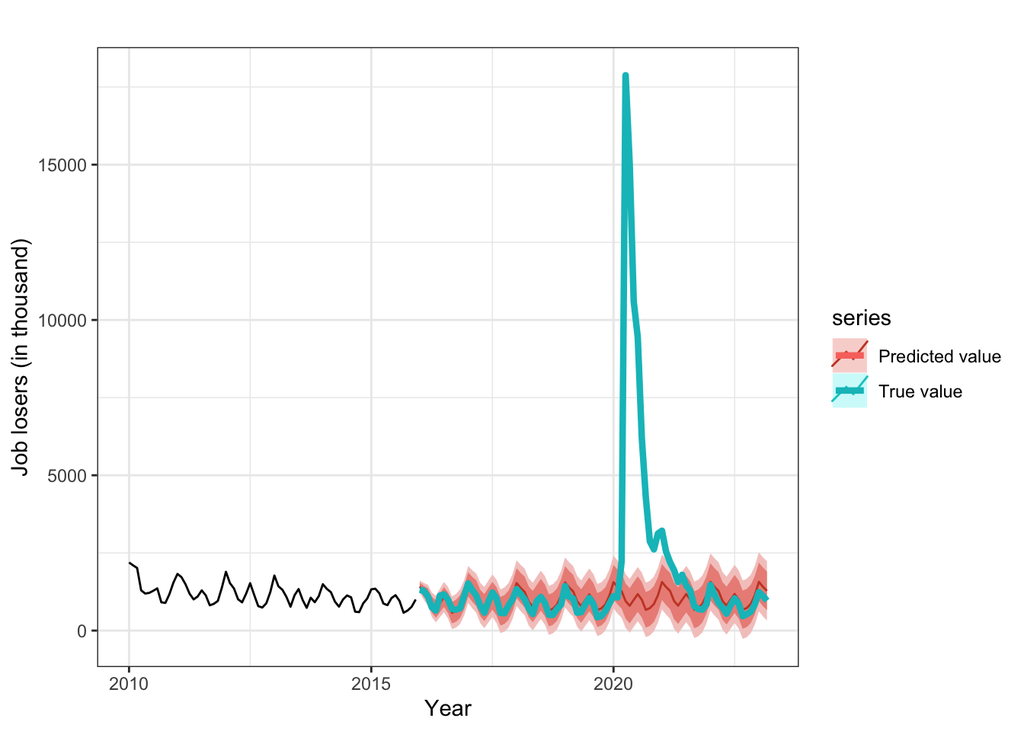

```r
# The time series plot showing the actual values and the predicted values
autoplot(window(layoff.train, start=c(2010,1))) +
  autolayer(layoff.forecast, series="Predicted value") +
  autolayer(layoff.test, series="True value", size=1.5) +
  labs(x="Year", y="Job losers (in thousand)") +
  theme_bw()
```

```r
# The accuracy of the fitted SARIMA model
accuracy(layoff.forecast, layoff.test)
```

```
##                      ME       RMSE       MAE        MPE      MAPE      MASE
## Training set   3.343086   98.69252  72.43905 -0.1744826  7.350393 0.3509744
## Test set     714.907816 2862.03924 953.28209 -1.5529392 29.408756 4.6187469
##                     ACF1 Theil's U
## Training set 0.001411822        NA
## Test set     0.771811950  1.074381
```

We can see that our SARIMA model alone does a very good job in forecasting, with the exception that it is not able to predict the “shock” as we expected. As a result, the test errors are noticeably bigger than the train errors.

**Conclusion:** Although, we fitted a SARIMA-ARCH model, making prediction based on that hybrid model is an extremely difficult task, which is not of our scope in the study. However, we expect that it would still not be able to account for such a huge spike in our original time series. All in all, no matter how best our trained model is, there is no way that it can predict the “COVID-19 shock”.